# examples_0427

Evaluate the expression below.

$$3\cdot 10^{4}+9\cdot 10^{3}+1\cdot
10^{2}+8\cdot 10^{1}+4\cdot 10^{0}$$

This is easier than it looks.

$$3\cdot 10^{4}+9\cdot 10^{3}+1\cdot
10^{2}+8\cdot 10^{1}+4\cdot 10^{0}$$

$$3\cdot 10000+9\cdot 1000+1\cdot
100+8\cdot 10+4\cdot 1$$

$$30000+9000+100+80+4$$

$$39184$$

Evaluate the expression below.

$$7\cdot 10^{3}+8\cdot 10^{2}+1\cdot
10^{1}+6\cdot 10^{0}$$

This is easier than it looks.

$$7\cdot 10^{3}+8\cdot 10^{2}+1\cdot
10^{1}+6\cdot 10^{0}$$

$$7\cdot 1000+8\cdot 100+1\cdot 10+6\cdot
1$$

$$7000+800+10+6$$

$$7816$$

Evaluate the expression below.

$$3\cdot 10^{3}+9\cdot 10^{2}+4\cdot
10^{1}+8\cdot 10^{0}$$

This is easier than it looks.

$$3\cdot 10^{3}+9\cdot 10^{2}+4\cdot
10^{1}+8\cdot 10^{0}$$

$$3\cdot 1000+9\cdot 100+4\cdot 10+8\cdot
1$$

$$3000+900+40+8$$

$$3948$$

Evaluate the expression below.

$$7\cdot 10^{4}+2\cdot 10^{3}+3\cdot
10^{2}+9\cdot 10^{1}+1\cdot 10^{0}$$

This is easier than it looks.

$$7\cdot 10^{4}+2\cdot 10^{3}+3\cdot
10^{2}+9\cdot 10^{1}+1\cdot 10^{0}$$

$$7\cdot 10000+2\cdot 1000+3\cdot
100+9\cdot 10+1\cdot 1$$

$$70000+2000+300+90+1$$

$$72391$$

Evaluate the expression below.

$$8\cdot 10^{4}+9\cdot 10^{3}+4\cdot
10^{2}+2\cdot 10^{1}+3\cdot 10^{0}$$

This is easier than it looks.

$$8\cdot 10^{4}+9\cdot 10^{3}+4\cdot
10^{2}+2\cdot 10^{1}+3\cdot 10^{0}$$

$$8\cdot 10000+9\cdot 1000+4\cdot
100+2\cdot 10+3\cdot 1$$

$$80000+9000+400+20+3$$

$$89423$$

Evaluate the expression below.

$$7\cdot 10^{3}+6\cdot 10^{2}+8\cdot
10^{1}+2\cdot 10^{0}$$

This is easier than it looks.

$$7\cdot 10^{3}+6\cdot 10^{2}+8\cdot
10^{1}+2\cdot 10^{0}$$

$$7\cdot 1000+6\cdot 100+8\cdot 10+2\cdot
1$$

$$7000+600+80+2$$

$$7682$$

As an alien-human translator, you run into this alien number:

[figure not shown]

What number is represented (expressed in our base-10 human way)?

Each symbol represents a number between 0 and 4. Each position represents a power of 5. The total value is found by adding up the products of each symbol's value times its corresponding power of 5.

$$4\cdot 5^{6}+1\cdot 5^{5}+3\cdot
5^{4}+0\cdot 5^{3}+1\cdot 5^{2}+2\cdot 5^{1}+0\cdot 5^{0}$$

You should get the answer:

$$67535$$

As an alien-human translator, you run into this alien number:

[figure not shown]

What number is represented (expressed in our base-10 human way)?

Each symbol represents a number between 0 and 4. Each position represents a power of 5. The total value is found by adding up the products of each symbol's value times its corresponding power of 5.

$$4\cdot 5^{6}+1\cdot 5^{5}+2\cdot
5^{4}+0\cdot 5^{3}+3\cdot 5^{2}+2\cdot 5^{1}+0\cdot 5^{0}$$

You should get the answer:

$$66960$$

As an alien-human translator, you run into this alien number:

[figure not shown]

What number is represented (expressed in our base-10 human way)?

Each symbol represents a number between 0 and 4. Each position represents a power of 5. The total value is found by adding up the products of each symbol's value times its corresponding power of 5.

$$4\cdot 5^{6}+3\cdot 5^{5}+4\cdot
5^{4}+2\cdot 5^{3}+1\cdot 5^{2}+0\cdot 5^{1}+0\cdot 5^{0}$$

You should get the answer:

$$74650$$

As an alien-human translator, you run into this alien number:

[figure not shown]

What number is represented (expressed in our base-10 human way)?

Each symbol represents a number between 0 and 4. Each position represents a power of 5. The total value is found by adding up the products of each symbol's value times its corresponding power of 5.

$$2\cdot 5^{5}+0\cdot 5^{4}+3\cdot
5^{3}+1\cdot 5^{2}+3\cdot 5^{1}+4\cdot 5^{0}$$

You should get the answer:

$$6669$$

As an alien-human translator, you run into this alien number:

[figure not shown]

What number is represented (expressed in our base-10 human way)?

Each symbol represents a number between 0 and 4. Each position represents a power of 5. The total value is found by adding up the products of each symbol's value times its corresponding power of 5.

$$1\cdot 5^{5}+1\cdot 5^{4}+4\cdot
5^{3}+2\cdot 5^{2}+3\cdot 5^{1}+0\cdot 5^{0}$$

You should get the answer:

$$4315$$

As an alien-human translator, you run into this alien number:

[figure not shown]

What number is represented (expressed in our base-10 human way)?

Each symbol represents a number between 0 and 4. Each position represents a power of 5. The total value is found by adding up the products of each symbol's value times its corresponding power of 5.

$$4\cdot 5^{5}+4\cdot 5^{4}+2\cdot
5^{3}+3\cdot 5^{2}+1\cdot 5^{1}+0\cdot 5^{0}$$

You should get the answer:

$$15330$$

Consider an alien society that uses base-8 number system with the following symbols:

| Human number | Alien numeral |
| --- | --- |
| 0 | 0 |
| 1 | A |
| 2 | B |
| 3 | C |
| 4 | D |
| 5 | E |
| 6 | F |
| 7 | G |

Notice, the alien 0 is the same as our 0, but then they use uppercase letters in the order of our alphabet instead of Arabic numerals.

A human wants to convert the number 312 to Alien. Do this for them.

Divide 312 by the base 8 to get a quotient and remainder.
$$\frac{312}{8}~=~39+\frac{0}{8}$$

(The quotient was 39 and the remainder was 0.)

Divide 39 by the base 8 to get a quotient and remainder.
$$\frac{39}{8}~=~4+\frac{7}{8}$$

(The quotient was 4 and the remainder was 7.)

Divide 4 by the base 8 to get a quotient and remainder.
$$\frac{4}{8}~=~0+\frac{4}{8}$$

(The quotient was 0 and the remainder was 4.)

Now, write down the remainders in reverse order.

$$\text{remainders}~=~4, 7, 0$$

And, lastly, use the table to convert those amounts into alien symbols.

The answer: `DG0`

Consider an alien society that uses base-8 number system with the following symbols:

| Human number | Alien numeral |
| --- | --- |
| 0 | 0 |
| 1 | A |
| 2 | B |
| 3 | C |
| 4 | D |
| 5 | E |
| 6 | F |
| 7 | G |

Notice, the alien 0 is the same as our 0, but then they use uppercase letters in the order of our alphabet instead of Arabic numerals.

A human wants to convert the number 267 to Alien. Do this for them.

Divide 267 by the base 8 to get a quotient and remainder.
$$\frac{267}{8}~=~33+\frac{3}{8}$$

(The quotient was 33 and the remainder was 3.)

Divide 33 by the base 8 to get a quotient and remainder.
$$\frac{33}{8}~=~4+\frac{1}{8}$$

(The quotient was 4 and the remainder was 1.)

Divide 4 by the base 8 to get a quotient and remainder.
$$\frac{4}{8}~=~0+\frac{4}{8}$$

(The quotient was 0 and the remainder was 4.)

Now, write down the remainders in reverse order.

$$\text{remainders}~=~4, 1, 3$$

And, lastly, use the table to convert those amounts into alien symbols.

The answer: `DAC`

Consider an alien society that uses base-4 number system with the following symbols:

| Human number | Alien numeral |
| --- | --- |
| 0 | 0 |
| 1 | A |
| 2 | B |
| 3 | C |

Notice, the alien 0 is the same as our 0, but then they use uppercase letters in the order of our alphabet instead of Arabic numerals.

A human wants to convert the number 411 to Alien. Do this for them.

Divide 411 by the base 4 to get a quotient and remainder.
$$\frac{411}{4}~=~102+\frac{3}{4}$$

(The quotient was 102 and the remainder was 3.)

Divide 102 by the base 4 to get a quotient and remainder.
$$\frac{102}{4}~=~25+\frac{2}{4}$$

(The quotient was 25 and the remainder was 2.)

Divide 25 by the base 4 to get a quotient and remainder.
$$\frac{25}{4}~=~6+\frac{1}{4}$$

(The quotient was 6 and the remainder was 1.)

Divide 6 by the base 4 to get a quotient and remainder.
$$\frac{6}{4}~=~1+\frac{2}{4}$$

(The quotient was 1 and the remainder was 2.)

Divide 1 by the base 4 to get a quotient and remainder.
$$\frac{1}{4}~=~0+\frac{1}{4}$$

(The quotient was 0 and the remainder was 1.)

Now, write down the remainders in reverse order.

$$\text{remainders}~=~1, 2, 1, 2,
3$$

And, lastly, use the table to convert those amounts into alien symbols.

The answer: `ABABC`

Consider an alien society that uses base-5 number system with the following symbols:

| Human number | Alien numeral |
| --- | --- |
| 0 | 0 |
| 1 | A |
| 2 | B |
| 3 | C |
| 4 | D |

Notice, the alien 0 is the same as our 0, but then they use uppercase letters in the order of our alphabet instead of Arabic numerals.

A human wants to convert the number 560 to Alien. Do this for them.

Divide 560 by the base 5 to get a quotient and remainder.
$$\frac{560}{5}~=~112+\frac{0}{5}$$

(The quotient was 112 and the remainder was 0.)

Divide 112 by the base 5 to get a quotient and remainder.
$$\frac{112}{5}~=~22+\frac{2}{5}$$

(The quotient was 22 and the remainder was 2.)

Divide 22 by the base 5 to get a quotient and remainder.
$$\frac{22}{5}~=~4+\frac{2}{5}$$

(The quotient was 4 and the remainder was 2.)

Divide 4 by the base 5 to get a quotient and remainder.
$$\frac{4}{5}~=~0+\frac{4}{5}$$

(The quotient was 0 and the remainder was 4.)

Now, write down the remainders in reverse order.

$$\text{remainders}~=~4, 2, 2,
0$$

And, lastly, use the table to convert those amounts into alien symbols.

The answer: `DBB0`

Consider an alien society that uses base-5 number system with the following symbols:

| Human number | Alien numeral |
| --- | --- |
| 0 | 0 |
| 1 | A |
| 2 | B |
| 3 | C |
| 4 | D |

Notice, the alien 0 is the same as our 0, but then they use uppercase letters in the order of our alphabet instead of Arabic numerals.

A human wants to convert the number 177 to Alien. Do this for them.

Divide 177 by the base 5 to get a quotient and remainder.
$$\frac{177}{5}~=~35+\frac{2}{5}$$

(The quotient was 35 and the remainder was 2.)

Divide 35 by the base 5 to get a quotient and remainder.
$$\frac{35}{5}~=~7+\frac{0}{5}$$

(The quotient was 7 and the remainder was 0.)

Divide 7 by the base 5 to get a quotient and remainder.
$$\frac{7}{5}~=~1+\frac{2}{5}$$

(The quotient was 1 and the remainder was 2.)

Divide 1 by the base 5 to get a quotient and remainder.
$$\frac{1}{5}~=~0+\frac{1}{5}$$

(The quotient was 0 and the remainder was 1.)

Now, write down the remainders in reverse order.

$$\text{remainders}~=~1, 2, 0,
2$$

And, lastly, use the table to convert those amounts into alien symbols.

The answer: `AB0B`

Consider an alien society that uses base-6 number system with the following symbols:

| Human number | Alien numeral |
| --- | --- |
| 0 | 0 |
| 1 | A |
| 2 | B |
| 3 | C |
| 4 | D |
| 5 | E |

Notice, the alien 0 is the same as our 0, but then they use uppercase letters in the order of our alphabet instead of Arabic numerals.

A human wants to convert the number 209 to Alien. Do this for them.

Divide 209 by the base 6 to get a quotient and remainder.
$$\frac{209}{6}~=~34+\frac{5}{6}$$

(The quotient was 34 and the remainder was 5.)

Divide 34 by the base 6 to get a quotient and remainder.
$$\frac{34}{6}~=~5+\frac{4}{6}$$

(The quotient was 5 and the remainder was 4.)

Divide 5 by the base 6 to get a quotient and remainder.
$$\frac{5}{6}~=~0+\frac{5}{6}$$

(The quotient was 0 and the remainder was 5.)

Now, write down the remainders in reverse order.

$$\text{remainders}~=~5, 4, 5$$

And, lastly, use the table to convert those amounts into alien symbols.

The answer: `EDE`

An alien society uses a base-8 positional numbering system. Luckily, they use the same symbol "0" for zero, and then symbols that match our uppercase letters. Below represents their single-digit addition table.

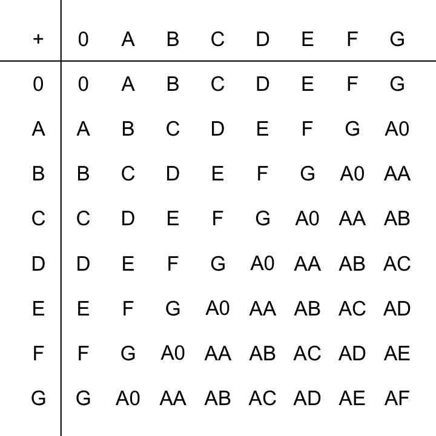

Use that table to add:

FAE + C0A

The answer is `AAAF`.

An alien society uses a base-6 positional numbering system. Luckily, they use the same symbol "0" for zero, and then symbols that match our uppercase letters. Below represents their single-digit addition table.

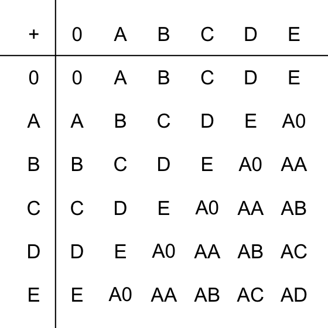

Use that table to add:

A0AC + ADDD

The answer is `BE0A`.

An alien society uses a base-8 positional numbering system. Luckily, they use the same symbol "0" for zero, and then symbols that match our uppercase letters. Below represents their single-digit addition table.

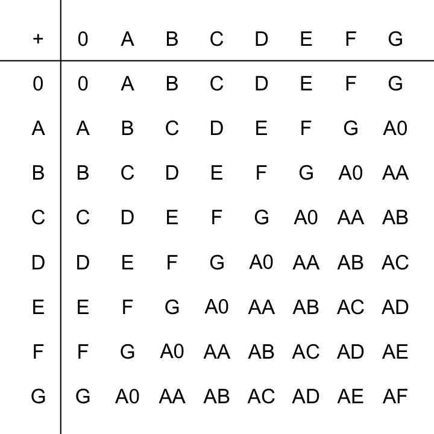

Use that table to add:

FAF + E00

The answer is `ACAF`.

An alien society uses a base-9 positional numbering system. Luckily, they use the same symbol "0" for zero, and then symbols that match our uppercase letters. Below represents their single-digit addition table.

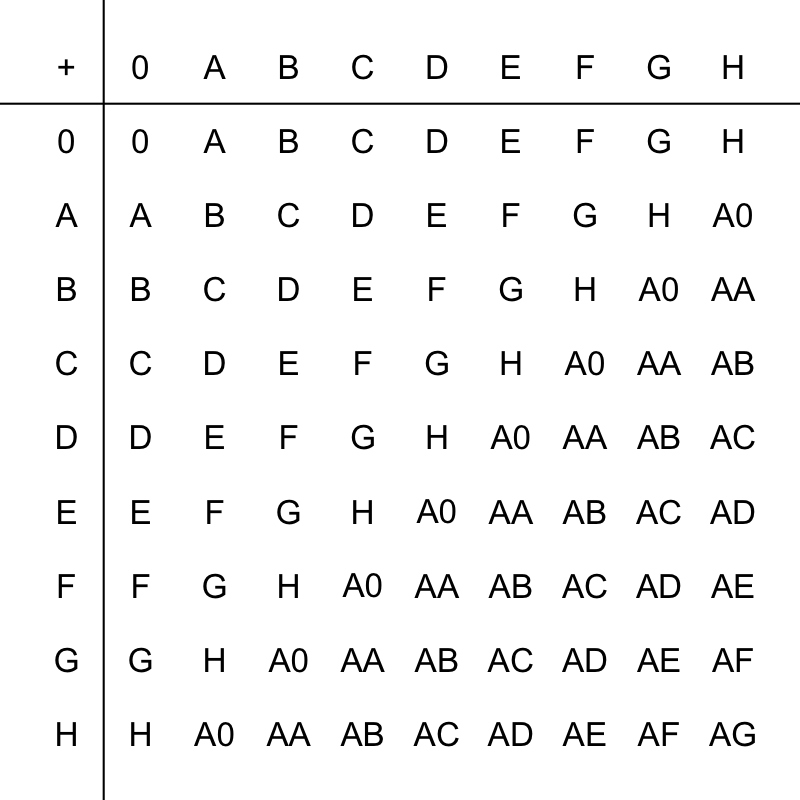

Use that table to add:

BD0 + DHB

The answer is `GCB`.

An alien society uses a base-7 positional numbering system. Luckily, they use the same symbol "0" for zero, and then symbols that match our uppercase letters. Below represents their single-digit addition table.

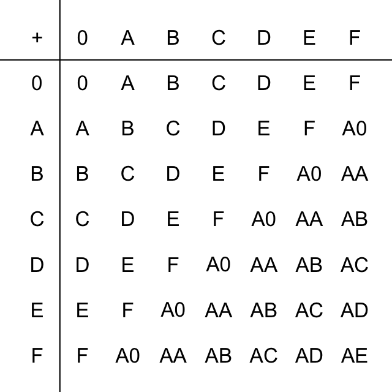

Use that table to add:

AACE + A0BE

The answer is `BAFC`.

An alien society uses a base-9 positional numbering system. Luckily, they use the same symbol "0" for zero, and then symbols that match our uppercase letters. Below represents their single-digit addition table.

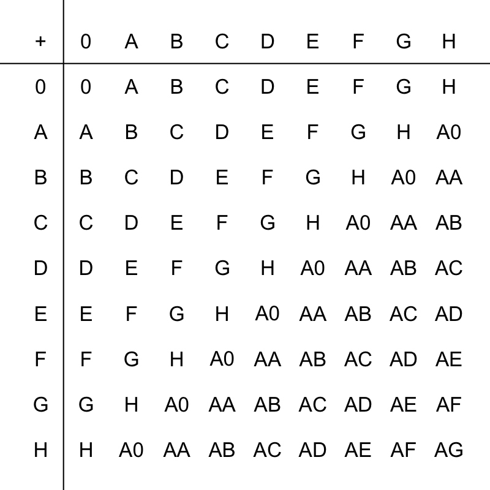

Use that table to add:

CBF + DH0

The answer is `HAF`.

The answer is `D0BCE`.

An alien society uses a base-8 positional numbering system. Luckily, they use the same symbol "0" for zero, and then symbols that match our uppercase letters. Below represents their single-digit addition table and single-digit multiplication table.

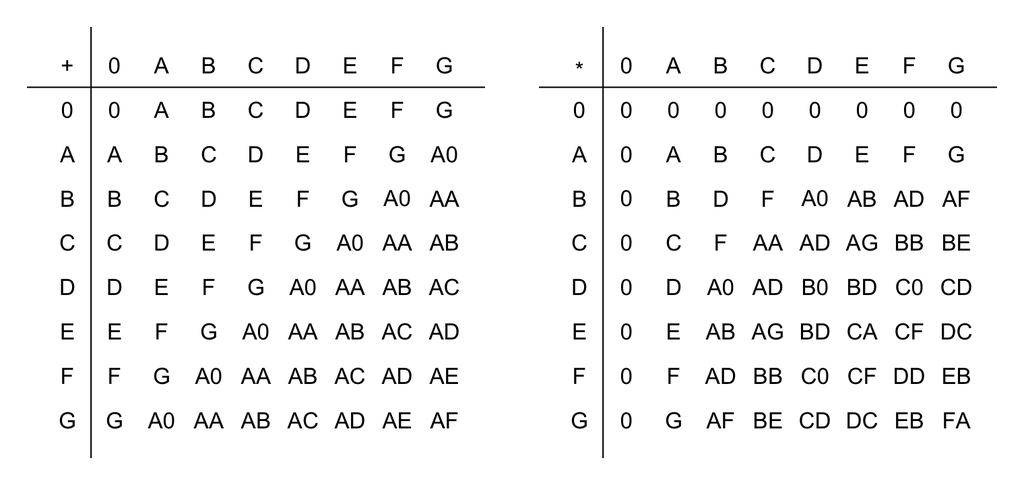

Use those tables to multiply:

BED * AEA

The answer is `DCBAD`.

An alien society uses a base-9 positional numbering system. Luckily, they use the same symbol "0" for zero, and then symbols that match our uppercase letters. Below represents their single-digit addition table and single-digit multiplication table.

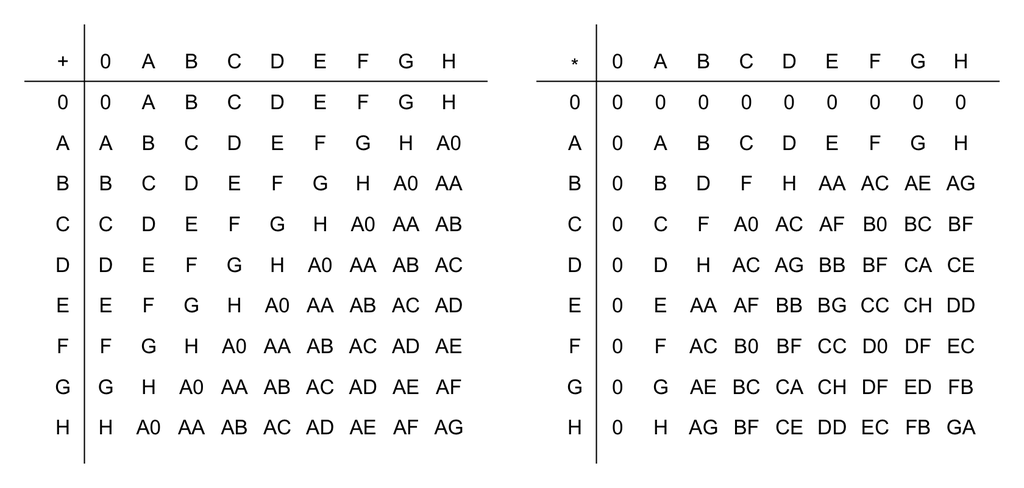

Use those tables to multiply:

AFD * AGH

The answer is `CAHGE`.

The answer is `FD0FF`.

An alien society uses a base-9 positional numbering system. Luckily, they use the same symbol "0" for zero, and then symbols that match our uppercase letters. Below represents their single-digit addition table and single-digit multiplication table.

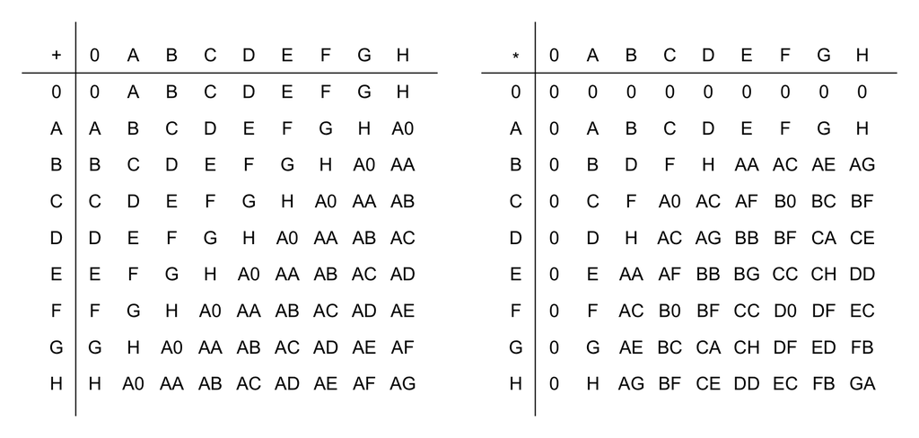

Use those tables to multiply:

AEG * H0

The answer is `ADAB0`.

The answer is `CDEDB`.